# Introduction

The datasets contains transactions made by credit cards in September 2013 by european cardholders. This dataset presents transactions that occurred in two days, where we have 492 frauds out of 284,807 transactions. The dataset is highly unbalanced, the positive class (frauds) account for 0.172% of all transactions.

It contains only numerical input variables which are the result of a PCA transformation. Unfortunately, due to confidentiality issues, we cannot provide the original features and more background information about the data. Features V1, V2, ... V28 are the principal components obtained with PCA, the only features which have not been transformed with PCA are 'Time' and 'Amount'. Feature 'Time' contains the seconds elapsed between each transaction and the first transaction in the dataset. The feature 'Amount' is the transaction Amount, this feature can be used for example-dependant cost-senstive learning. Feature 'Class' is the response variable and it takes value 1 in case of fraud and 0 otherwise.

```python
## Using IBM Cloud

# import types
# import pandas as pd
# from botocore.client import Config
# import ibm_boto3

# def __iter__(self): return 0

# # @hidden_cell
# # The following code accesses a file in your IBM Cloud Object Storage. It includes your credentials.
# # You might want to remove those credentials before you share your notebook.
# client_dcc662e2032147378976f288b5e93fcc = ibm_boto3.client(service_name='s3',
#     ibm_api_key_id='pGKI3UAgcg9d2BDY9-eXqh5g00qv-R-AJryFg9j6-0gJ',
#     ibm_auth_endpoint="https://iam.bluemix.net/oidc/token",
#     config=Config(signature_version='oauth'),
#     endpoint_url='https://s3-api.us-geo.objectstorage.service.networklayer.com')

# body = client_dcc662e2032147378976f288b5e93fcc.get_object(Bucket='default-donotdelete-pr-fdm7x0ad5ee1ku',Key='creditcard.csv')['Body']
# # add missing __iter__ method, so pandas accepts body as file-like object
# if not hasattr(body, "__iter__"): body.__iter__ = types.MethodType( __iter__, body )

# df = pd.read_csv(body)
# df.head()
```

[output not shown]

5 rows × 31 columns

```python
# running on local machine
import pandas as pd
df = pd.read_csv('creditcardfraud/creditcard.csv')
```

```python
# it has 28 features plus time and amount variables
df.columns
```

```
Index(['Time', 'V1', 'V2', 'V3', 'V4', 'V5', 'V6', 'V7', 'V8', 'V9', 'V10',
       'V11', 'V12', 'V13', 'V14', 'V15', 'V16', 'V17', 'V18', 'V19', 'V20',
       'V21', 'V22', 'V23', 'V24', 'V25', 'V26', 'V27', 'V28', 'Amount',
       'Class'],
      dtype='object')
```

```python
# take a look at the statistics of these features
df.describe()
```

|  | Time | V1 | V2 | V3 | V4 | V5 | V6 | V7 | V8 | V9 | ... | V21 | V22 | V23 | V24 | V25 | V26 | V27 | V28 | Amount | Class |
| --- | --- | --- | --- | --- | --- | --- | --- | --- | --- | --- | --- | --- | --- | --- | --- | --- | --- | --- | --- | --- | --- |
| count | 284807.000000 | 2.848070e+05 | 2.848070e+05 | 2.848070e+05 | 2.848070e+05 | 2.848070e+05 | 2.848070e+05 | 2.848070e+05 | 2.848070e+05 | 2.848070e+05 | ... | 2.848070e+05 | 2.848070e+05 | 2.848070e+05 | 2.848070e+05 | 2.848070e+05 | 2.848070e+05 | 2.848070e+05 | 2.848070e+05 | 284807.000000 | 284807.000000 |
| mean | 94813.859575 | 3.919560e-15 | 5.688174e-16 | -8.769071e-15 | 2.782312e-15 | -1.552563e-15 | 2.010663e-15 | -1.694249e-15 | -1.927028e-16 | -3.137024e-15 | ... | 1.537294e-16 | 7.959909e-16 | 5.367590e-16 | 4.458112e-15 | 1.453003e-15 | 1.699104e-15 | -3.660161e-16 | -1.206049e-16 | 88.349619 | 0.001727 |
| std | 47488.145955 | 1.958696e+00 | 1.651309e+00 | 1.516255e+00 | 1.415869e+00 | 1.380247e+00 | 1.332271e+00 | 1.237094e+00 | 1.194353e+00 | 1.098632e+00 | ... | 7.345240e-01 | 7.257016e-01 | 6.244603e-01 | 6.056471e-01 | 5.212781e-01 | 4.822270e-01 | 4.036325e-01 | 3.300833e-01 | 250.120109 | 0.041527 |
| min | 0.000000 | -5.640751e+01 | -7.271573e+01 | -4.832559e+01 | -5.683171e+00 | -1.137433e+02 | -2.616051e+01 | -4.355724e+01 | -7.321672e+01 | -1.343407e+01 | ... | -3.483038e+01 | -1.093314e+01 | -4.480774e+01 | -2.836627e+00 | -1.029540e+01 | -2.604551e+00 | -2.256568e+01 | -1.543008e+01 | 0.000000 | 0.000000 |
| 25% | 54201.500000 | -9.203734e-01 | -5.985499e-01 | -8.903648e-01 | -8.486401e-01 | -6.915971e-01 | -7.682956e-01 | -5.540759e-01 | -2.086297e-01 | -6.430976e-01 | ... | -2.283949e-01 | -5.423504e-01 | -1.618463e-01 | -3.545861e-01 | -3.171451e-01 | -3.269839e-01 | -7.083953e-02 | -5.295979e-02 | 5.600000 | 0.000000 |
| 50% | 84692.000000 | 1.810880e-02 | 6.548556e-02 | 1.798463e-01 | -1.984653e-02 | -5.433583e-02 | -2.741871e-01 | 4.010308e-02 | 2.235804e-02 | -5.142873e-02 | ... | -2.945017e-02 | 6.781943e-03 | -1.119293e-02 | 4.097606e-02 | 1.659350e-02 | -5.213911e-02 | 1.342146e-03 | 1.124383e-02 | 22.000000 | 0.000000 |
| 75% | 139320.500000 | 1.315642e+00 | 8.037239e-01 | 1.027196e+00 | 7.433413e-01 | 6.119264e-01 | 3.985649e-01 | 5.704361e-01 | 3.273459e-01 | 5.971390e-01 | ... | 1.863772e-01 | 5.285536e-01 | 1.476421e-01 | 4.395266e-01 | 3.507156e-01 | 2.409522e-01 | 9.104512e-02 | 7.827995e-02 | 77.165000 | 0.000000 |
| max | 172792.000000 | 2.454930e+00 | 2.205773e+01 | 9.382558e+00 | 1.687534e+01 | 3.480167e+01 | 7.330163e+01 | 1.205895e+02 | 2.000721e+01 | 1.559499e+01 | ... | 2.720284e+01 | 1.050309e+01 | 2.252841e+01 | 4.584549e+00 | 7.519589e+00 | 3.517346e+00 | 3.161220e+01 | 3.384781e+01 | 25691.160000 | 1.000000 |

8 rows × 31 columns

```python
# see if there is missing values
df.isnull().sum()
```

```
Time      0
V1        0
V2        0
V3        0
V4        0
V5        0
V6        0
V7        0
V8        0
V9        0
V10       0
V11       0
V12       0
V13       0
V14       0
V15       0
V16       0
V17       0
V18       0
V19       0
V20       0
V21       0
V22       0
V23       0
V24       0
V25       0
V26       0
V27       0
V28       0
Amount    0
Class     0
dtype: int64
```

```python
tmp = df.Class.value_counts()
print('No frauds: ', tmp[0])
print('Frauds: ', tmp[1])
```

```
No frauds:  284315
Frauds:  492
```

```python
import seaborn as sns
import matplotlib.pyplot as plt
import warnings
warnings.filterwarnings("ignore")
%matplotlib inline
```

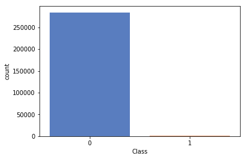

```python
# visualize the classes distribution
sns.countplot('Class', data=df, palette="muted")
```

As we can see from the above plot, our original dataset is extremely imbalanced. Most of the transactions are non-fraud. If we use this dataset without any modification to train our classifiers, then we will most certainly overfit.

```
(0.0, 172792.0)
```

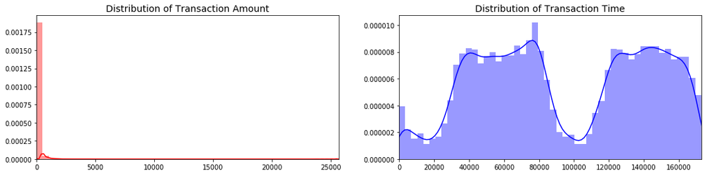

```python
# lets also examine the distributions of time and amount features
fig, ax = plt.subplots(1, 2, figsize=(18,4))

amount_val = df['Amount'].values
time_val = df['Time'].values

sns.distplot(amount_val, ax=ax[0], color='r')
ax[0].set_title('Distribution of Transaction Amount', fontsize=14)
ax[0].set_xlim([min(amount_val), max(amount_val)])

sns.distplot(time_val, ax=ax[1], color='b')
ax[1].set_title('Distribution of Transaction Time', fontsize=14)
ax[1].set_xlim([min(time_val), max(time_val)])
```

As shown in the above plots, both Time and Transaction Amount are needed to be scaled in order to improve model performances.

## Scaling Time and Amount

```python
from sklearn.preprocessing import RobustScaler
scaler = RobustScaler() # robust scaler is less prone to outliers
df['scaled_time'] = scaler.fit_transform(df.Time.values.reshape(-1,1))
df['scaled_amount'] = scaler.fit_transform(df.Amount.values.reshape(-1,1))
df.drop(['Time', 'Amount'], axis=1, inplace=True)
```

```python
df.head()
```

|  | V1 | V2 | V3 | V4 | V5 | V6 | V7 | V8 | V9 | V10 | ... | V22 | V23 | V24 | V25 | V26 | V27 | V28 | Class | scaled_time | scaled_amount |
| --- | --- | --- | --- | --- | --- | --- | --- | --- | --- | --- | --- | --- | --- | --- | --- | --- | --- | --- | --- | --- | --- |
| 0 | -1.359807 | -0.072781 | 2.536347 | 1.378155 | -0.338321 | 0.462388 | 0.239599 | 0.098698 | 0.363787 | 0.090794 | ... | 0.277838 | -0.110474 | 0.066928 | 0.128539 | -0.189115 | 0.133558 | -0.021053 | 0 | -0.994983 | 1.783274 |
| 1 | 1.191857 | 0.266151 | 0.166480 | 0.448154 | 0.060018 | -0.082361 | -0.078803 | 0.085102 | -0.255425 | -0.166974 | ... | -0.638672 | 0.101288 | -0.339846 | 0.167170 | 0.125895 | -0.008983 | 0.014724 | 0 | -0.994983 | -0.269825 |
| 2 | -1.358354 | -1.340163 | 1.773209 | 0.379780 | -0.503198 | 1.800499 | 0.791461 | 0.247676 | -1.514654 | 0.207643 | ... | 0.771679 | 0.909412 | -0.689281 | -0.327642 | -0.139097 | -0.055353 | -0.059752 | 0 | -0.994972 | 4.983721 |
| 3 | -0.966272 | -0.185226 | 1.792993 | -0.863291 | -0.010309 | 1.247203 | 0.237609 | 0.377436 | -1.387024 | -0.054952 | ... | 0.005274 | -0.190321 | -1.175575 | 0.647376 | -0.221929 | 0.062723 | 0.061458 | 0 | -0.994972 | 1.418291 |
| 4 | -1.158233 | 0.877737 | 1.548718 | 0.403034 | -0.407193 | 0.095921 | 0.592941 | -0.270533 | 0.817739 | 0.753074 | ... | 0.798278 | -0.137458 | 0.141267 | -0.206010 | 0.502292 | 0.219422 | 0.215153 | 0 | -0.994960 | 0.670579 |

5 rows × 31 columns

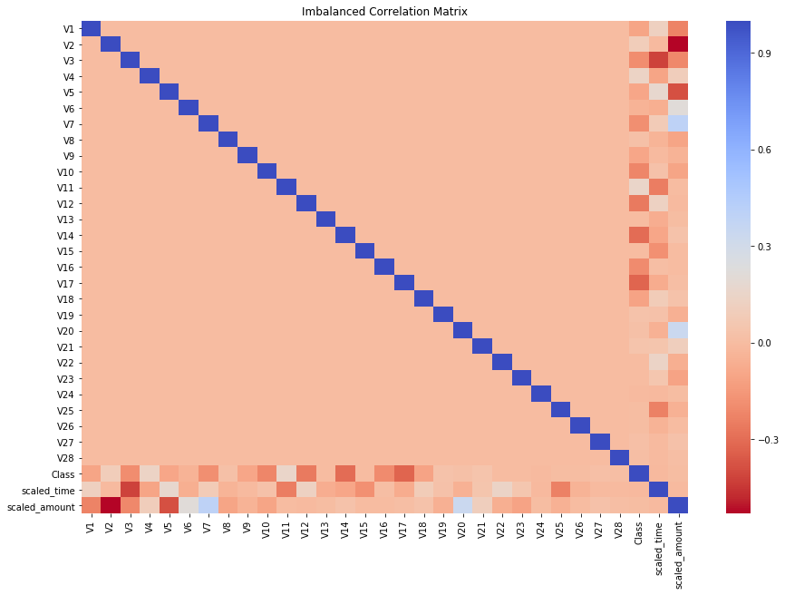

```python
# lets take a look at the correlation plot to examine features relation to classes
plt.figure(figsize=(15,10))
plt.title("Imbalanced Correlation Matrix")
sns.heatmap(df.corr(), cmap='coolwarm_r', annot_kws={'size':20})
```

```python
# shuffle the data
df = df.sample(frac=1)

frauds = df.loc[df.Class==1]
non_frauds = df.loc[df.Class==0][:429]
new_df = pd.concat([frauds, non_frauds])
new_df = new_df.sample(frac=1, random_state=2019)
new_df.head()
```

|  | V1 | V2 | V3 | V4 | V5 | V6 | V7 | V8 | V9 | V10 | ... | V22 | V23 | V24 | V25 | V26 | V27 | V28 | Class | scaled_time | scaled_amount |
| --- | --- | --- | --- | --- | --- | --- | --- | --- | --- | --- | --- | --- | --- | --- | --- | --- | --- | --- | --- | --- | --- |
| 140394 | -6.961676 | 3.882633 | -2.892660 | -0.057403 | -2.866139 | -0.721680 | -2.084298 | 3.463034 | 0.648002 | 1.615223 | ... | -0.418317 | 0.422675 | 0.056979 | 0.820109 | 0.273678 | 0.204325 | -0.354226 | 0 | -0.011666 | 0.156082 |
| 6472 | 1.023874 | 2.001485 | -4.769752 | 3.819195 | -1.271754 | -1.734662 | -3.059245 | 0.889805 | 0.415382 | -3.955812 | ... | -0.054196 | 0.709654 | -0.372216 | -2.032068 | 0.366778 | 0.395171 | 0.020206 | 1 | -0.904052 | -0.293440 |
| 259002 | 2.029039 | -0.928822 | 0.048696 | -0.724177 | -1.359196 | -0.319260 | -1.304253 | 0.183088 | 2.312593 | -0.422458 | ... | 0.667772 | 0.218061 | -0.387726 | -0.563044 | 0.713271 | -0.003171 | -0.047048 | 0 | 0.871967 | -0.293440 |
| 77099 | -0.075483 | 1.812355 | -2.566981 | 4.127549 | -1.628532 | -0.805895 | -3.390135 | 1.019353 | -2.451251 | -3.555835 | ... | 0.270471 | -0.143624 | 0.013566 | 0.634203 | 0.213693 | 0.773625 | 0.387434 | 1 | -0.326660 | -0.237546 |
| 105980 | 1.524484 | -1.053841 | 0.497467 | -1.442412 | -1.524713 | -0.646696 | -1.110334 | -0.120683 | -1.635291 | 1.425733 | ... | -0.843161 | 0.117493 | -0.185511 | 0.179495 | -0.377980 | 0.038188 | 0.024832 | 0 | -0.175319 | -0.033536 |

5 rows × 31 columns

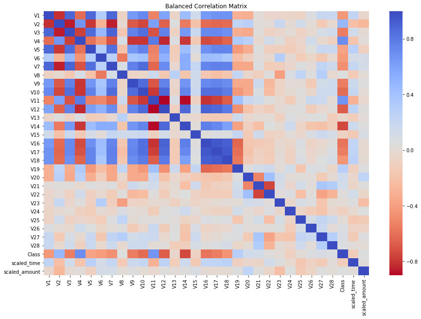

```python
plt.figure(figsize=(15,10))
plt.title("Balanced Correlation Matrix")
sns.heatmap(new_df.corr(), cmap='coolwarm_r', annot_kws={'size':20})
```

By comparing the two correlation matrix heatmaps, we can see that there is a noticible differences in correlations using balanced and imbalanced datasets, and we can observe more correled relations when using balanced datasets. Therefore, it suggests that we might want to use a more balanced datasets to train robust classifier.

# TSNE Algorithm to cluster our new balance sample

```python
from sklearn.manifold import TSNE
import matplotlib.patches as mpatches
from mpl_toolkits.mplot3d import Axes3D

def plot_tsne(dim=2):
    # New_df is from the random undersample data (fewer instances)
    X = new_df.drop('Class', axis=1)
    y = new_df['Class']
    blue_patch = mpatches.Patch(color='#0A0AFF', label='No Fraud')
    red_patch = mpatches.Patch(color='#AF0000', label='Fraud')

    # T-SNE Implementation
    X_reduced_tsne = TSNE(n_components=dim, random_state=2019).fit_transform(X.values)
    if dim == 3:
        fig = plt.figure(figsize=(10, 8))
        ax = fig.add_subplot(111, projection='3d')
        ax.scatter(X_reduced_tsne[:,0], X_reduced_tsne[:,1], X_reduced_tsne[:,2], c=(y == 0), cmap='coolwarm', label='No Fraud', linewidths=1)
        ax.scatter(X_reduced_tsne[:,0], X_reduced_tsne[:,1], X_reduced_tsne[:,2], c=(y == 1), cmap='coolwarm', label='No Fraud', linewidths=1)
        ax.set_title('t-SNE Clustering', fontsize=14)
        ax.grid(True)
        ax.legend(handles=[blue_patch, red_patch])
    elif dim == 2:
        plt.figure(figsize=(12,8))
        plt.scatter(X_reduced_tsne[:,0], X_reduced_tsne[:,1], c=(y == 0), cmap='coolwarm', label='No Fraud', linewidths=1)
        plt.scatter(X_reduced_tsne[:,0], X_reduced_tsne[:,1], c=(y == 1), cmap='coolwarm', label='Fraud', linewidths=1)
        plt.title('t-SNE Clustring', fontsize=14)
        plt.grid(True)
        plt.legend(handles=[blue_patch, red_patch])
    else:
        return print('invalid input dimension')
```

```
Wall time: 16.2 s
```

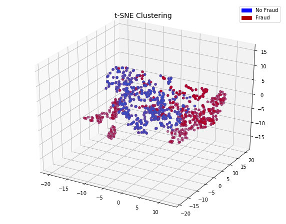

```python
%time plot_tsne(3)
```

```
Wall time: 5.23 s
```

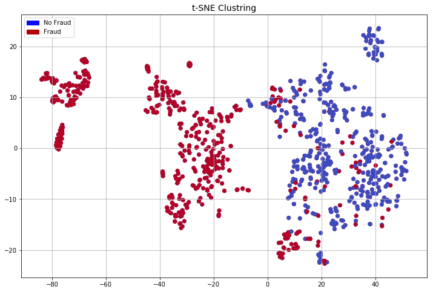

```python
%time plot_tsne(2)
```

# SMOTE (Synthetic Minority Over-sampling Technique)

We will use SMOTE to address to imbalanced datasets

- SMOTE will generate synthetic points from the minority class in order to make our training set more balance
- SMOTE will picks the distance between the closest neighbors of the minority class, in between these distances it creates synthetic points
- More information is obtained

```python
!pip install imbalanced-learn
```

# Train and Evaluate

```python
def plot_cm(cm):
    cm = pd.DataFrame(cm)
    sns.heatmap(cm, annot=True, fmt='.1f', cmap='YlGnBu', linewidths=5, vmax=500)
    plt.yticks(rotation=0)
    plt.show()
```

```python
from sklearn.model_selection import StratifiedShuffleSplit
from imblearn.over_sampling import SMOTE
from sklearn.metrics import precision_score, recall_score, f1_score, roc_auc_score, accuracy_score, classification_report, confusion_matrix
from sklearn.model_selection import GridSearchCV
import time

# split original datasets into features and label data
X = df.drop(['Class'], axis=1).values
y = df.Class.values


def cross_val(clf, grid_param=None, k=5, test=0.5, cv_test=0.2, plot=True):

    sss = StratifiedShuffleSplit(n_splits=1, test_size=test, random_state=2019)
    for trn_idx, tes_idx in sss.split(X,y):
        time1 = time.time()
        x_trn, x_tes = X[trn_idx], X[tes_idx]
        y_trn, y_tes = y[trn_idx], y[tes_idx]
        x_res, y_res = SMOTE(sampling_strategy='minority').fit_resample(x_trn, y_trn)
        auc = []

        k = 1 if grid_param else k # if use GridSearchCV, use one fold becuase GridSearchCV will perform k fold validation

        for fold, (tr_idx, te_idx) in enumerate(StratifiedShuffleSplit(n_splits=k, test_size=cv_test, random_state=2019).split(x_res, y_res)):
            Xtrain, Xtest = x_res[tr_idx], x_res[te_idx]
            ytrain, ytest = y_res[tr_idx], y_res[te_idx]
            if grid_param:
                cv = GridSearchCV(clf, grid_param, scoring='roc_auc', verbose=1, n_jobs=-1, cv=2)
                cv.fit(Xtrain, ytrain)
                score = roc_auc_score(ytest, cv.predict(Xtest))
                print(fold, ':', score)
                auc.append(score)
            else:
                clf.fit(Xtrain, ytrain)
                score = roc_auc_score(ytest, clf.predict(Xtest))
                print(fold, ':', score)
                auc.append(score)
        print(k, 'cv score: ', sum(auc)/len(auc))

        if grid_param:
            preds = cv.predict(x_tes)
            print('test score: ', roc_auc_score(y_tes, preds))
            print('best parameters: ', cv.best_params_)
        else:
            preds = clf.predict(x_tes)
            print('test score: ', roc_auc_score(y_tes, preds))

        print('Completion time:', time.time()-time1, 'seconds')

        if plot:
            cm = confusion_matrix(y_tes, preds)
            plot_cm(cm)
            print(classification_report(y_tes, preds))

    return cv if grid_param else clf
```

# Model Selection

```
LogisticRegression
0 : 0.9573004919877597
1 : 0.9576002290353881
2 : 0.9565618770830947
3 cv score:  0.9571541993687475
test score:  0.9223681551169962
Completion time: 13.247580289840698 seconds
```

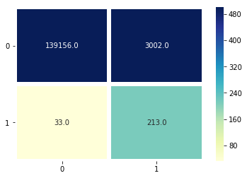

```
              precision    recall  f1-score   support

           0       1.00      0.98      0.99    142158
           1       0.07      0.87      0.12       246

   micro avg       0.98      0.98      0.98    142404
   macro avg       0.53      0.92      0.56    142404
weighted avg       1.00      0.98      0.99    142404

RandomForestClassifier
0 : 0.9998768992684299
1 : 0.9999120678133024
2 : 0.9999472425436129
3 cv score:  0.999912069875115
test score:  0.8881340034225058
Completion time: 31.9435932636261 seconds
```

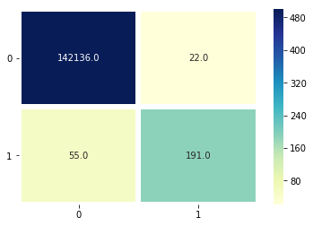

```
              precision    recall  f1-score   support

           0       1.00      1.00      1.00    142158
           1       0.90      0.78      0.83       246

   micro avg       1.00      1.00      1.00    142404
   macro avg       0.95      0.89      0.92    142404
weighted avg       1.00      1.00      1.00    142404

kNieghborsClassifier
0 : 0.9991207090602138
1 : 0.9990327459463262
2 : 0.9990855374226224
3 cv score:  0.999079664143054
test score:  0.9238893069511457
Completion time: 520.0365943908691 seconds
```

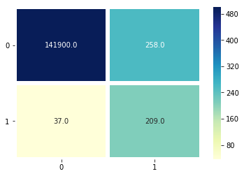

```
              precision    recall  f1-score   support

           0       1.00      1.00      1.00    142158
           1       0.45      0.85      0.59       246

   micro avg       1.00      1.00      1.00    142404
   macro avg       0.72      0.92      0.79    142404
weighted avg       1.00      1.00      1.00    142404

SVC
0 : 0.9994196679797411
1 : 0.9992437831944005
2 : 0.9992789814293754
3 cv score:  0.9993141442011724
test score:  0.8285824361008142
Completion time: 768.6259486675262 seconds
```

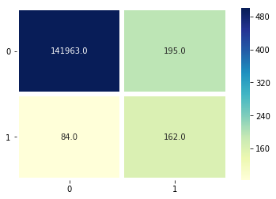

```
              precision    recall  f1-score   support

           0       1.00      1.00      1.00    142158
           1       0.45      0.66      0.54       246

   micro avg       1.00      1.00      1.00    142404
   macro avg       0.73      0.83      0.77    142404
weighted avg       1.00      1.00      1.00    142404

GradientBoostingClassifier
0 : 0.9926841466006605
1 : 0.9926490188796788
2 : 0.992561034735302
3 cv score:  0.9926314000718804
test score:  0.9257490548990662
Completion time: 222.79033279418945 seconds
```

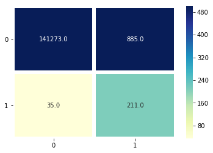

```
              precision    recall  f1-score   support

           0       1.00      0.99      1.00    142158
           1       0.19      0.86      0.31       246

   micro avg       0.99      0.99      0.99    142404
   macro avg       0.60      0.93      0.66    142404
weighted avg       1.00      0.99      1.00    142404
```

```python
from sklearn.linear_model import LogisticRegression
from sklearn.neighbors import KNeighborsClassifier
from sklearn.ensemble import RandomForestClassifier, GradientBoostingClassifier
from sklearn.svm import SVC

classifiers = {
    "LogisticRegression": LogisticRegression(),
    "RandomForestClassifier": RandomForestClassifier(),
    "kNieghborsClassifier": KNeighborsClassifier(),
    "SVC": SVC(),
    "GradientBoostingClassifier": GradientBoostingClassifier()
}

clfs = {}
for clf in classifiers:
    print(clf)
    clfs.setdefault(clf, cross_val(classifiers[clf], k=3))
```

We should look at our trained models, and determine how to set values for parameters tuning

```python
import pickle
for clf in clfs:
    pickle.dump(clfs[clf], open('models/'+clf+'_intial.sav', 'wb'))
```

```python
!dir models
```

[output not shown]

From the above results, we can see that GradientBoostingClassifer, RandomForestClassifier, and LogisticsClassifier did yield a relatively good results with a very fast completeion time, therefore, we can further fine tune these 3 models, and compare how they perform.

# Model Tuning

```python
# define parameters values

log_params = {"penalty": ['l1', 'l2'], 'C': [0.001, 0.01, 0.1, 1, 10, 100], "n_jobs": [-1]}
rf_params = {"min_samples_leaf": [1,3,5,10,25], "max_features": [1, 0.5, 'log2', 'sqrt'], "n_jobs": [-1]}
gb_params = {"min_samples_leaf": [100, 500], "max_depth": [5, 8], "subsample": [0.3, 0.8], "n_estimators":[20, 100, 200], "learning_rate": [0.1, 0.5], "tol":[0.001]}

params = {
    "LogisticRegression": log_params,
    "RandomForestClassifier": rf_params,
    "GradientBoostingClassifier": gb_params
}

classifiers = {
    "LogisticRegression": LogisticRegression(),
    "RandomForestClassifier": RandomForestClassifier(),
    "GradientBoostingClassifier": GradientBoostingClassifier()
}
```

```
Tuning LogisticRegression
Fitting 2 folds for each of 12 candidates, totalling 24 fits
```

```
[Parallel(n_jobs=-1)]: Using backend LokyBackend with 8 concurrent workers.
[Parallel(n_jobs=-1)]: Done  24 out of  24 | elapsed:   19.2s finished
```

```
0 : 0.9559990956246349
1 cv score:  0.9559990956246349
test score:  0.924386606589233
best parameters:  {'C': 100, 'n_jobs': -1, 'penalty': 'l2'}
Completion time: 25.183666944503784 seconds
```

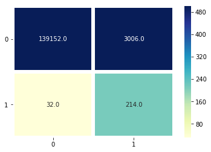

```
              precision    recall  f1-score   support

           0       1.00      0.98      0.99    142158
           1       0.07      0.87      0.12       246

   micro avg       0.98      0.98      0.98    142404
   macro avg       0.53      0.92      0.56    142404
weighted avg       1.00      0.98      0.99    142404

Tuning RandomForestClassifier
Fitting 2 folds for each of 20 candidates, totalling 40 fits
```

```
[Parallel(n_jobs=-1)]: Using backend LokyBackend with 8 concurrent workers.
[Parallel(n_jobs=-1)]: Done  40 out of  40 | elapsed:   51.6s finished
```

```
0 : 0.9997537972997723
1 cv score:  0.9997537972997723
test score:  0.8819063055569567
best parameters:  {'max_features': 1, 'min_samples_leaf': 5, 'n_jobs': -1}
Completion time: 53.95374536514282 seconds
```

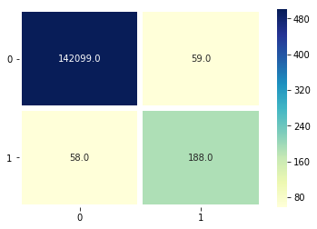

```
              precision    recall  f1-score   support

           0       1.00      1.00      1.00    142158
           1       0.76      0.76      0.76       246

   micro avg       1.00      1.00      1.00    142404
   macro avg       0.88      0.88      0.88    142404
weighted avg       1.00      1.00      1.00    142404

Tuning GradientBoostingClassifier
Fitting 2 folds for each of 48 candidates, totalling 96 fits
```

```
[Parallel(n_jobs=-1)]: Using backend LokyBackend with 8 concurrent workers.
[Parallel(n_jobs=-1)]: Done  34 tasks      | elapsed: 12.7min
[Parallel(n_jobs=-1)]: Done  96 out of  96 | elapsed: 36.5min finished
```

```
0 : 0.9997362127180642
1 cv score:  0.9997362127180642
test score:  0.9081743124019683
best parameters:  {'learning_rate': 0.5, 'max_depth': 5, 'min_samples_leaf': 500, 'n_estimators': 100, 'subsample': 0.3, 'tol': 0.001}
Completion time: 2246.9703459739685 seconds
```

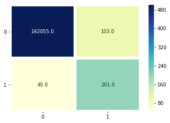

```
              precision    recall  f1-score   support

           0       1.00      1.00      1.00    142158
           1       0.66      0.82      0.73       246

   micro avg       1.00      1.00      1.00    142404
   macro avg       0.83      0.91      0.87    142404
weighted avg       1.00      1.00      1.00    142404
```

```python
clfs_tuned = {}
for clf in classifiers:
    print('Tuning', clf)
    clfs_tuned.setdefault(clf, cross_val(classifiers[clf], grid_param=params[clf]))
```

```python
# saving models
for clf in clfs_tuned:
    pickle.dump(clfs_tuned[clf], open('models/'+clf+'_tuned.sav', 'wb'))
```

```python
!dir models
```

```
 Volume in drive C has no label.
 Volume Serial Number is 244D-FC98

 Directory of C:\Users\michael\Desktop\coursera\Advanced Data Science with IBM Specialization\Data Science Capstone\models

05/02/2019  05:17 PM    <DIR>          .
05/02/2019  05:17 PM    <DIR>          ..
05/02/2019  04:16 PM           135,848 GradientBoostingClassifier_intial.sav
05/02/2019  05:17 PM           243,511 GradientBoostingClassifier_tuned.sav
05/02/2019  04:16 PM        61,512,819 kNieghborsClassifier_intial.sav
05/02/2019  04:16 PM             1,042 LogisticRegression_intial.sav
05/02/2019  05:17 PM             5,617 LogisticRegression_tuned.sav
05/02/2019  04:16 PM           721,425 RandomForestClassifier_intial.sav
05/02/2019  05:17 PM         1,496,013 RandomForestClassifier_tuned.sav
05/02/2019  04:16 PM         1,164,080 SVC_intial.sav
               8 File(s)     65,280,355 bytes
               2 Dir(s)  865,669,206,016 bytes free
```